# xwMOOC 데이터 과학

2018년 달력

xwMOOC

2018-01-14

## 1. 공휴일 달력 만들기

매년 새해가 되면 나름대로 계획을 세우고 이를 달력에 표시한다. `ggplot`을 통해 달력을 만드는 것이 일반적이지는 않지만 가능하다.

## 2. 공공데이터 휴일 정보 데이터

### 2.1. 환경설정

먼저 달력만들기 위해서 필요한 R 팩키지 ggcal를 가져와서 한글 관련 몇가지 설정을 한다. 그리고, [공공데이터 포털](https://www.data.go.kr/)에서 “특일 정보” 라는 제목으로 API 를 제공(https://www.data.go.kr/dataset/15012690/openapi.do)하고 있어 이를 R에서 받아오는데 필요한 몇가지 팩키지와 데이터 전처리에 필요한 몇가지 팩키지를 설치한다.

```r
# 0. 환경설정 -----
library(glue)
library(XML)
library(stringr)
library(purrr)
library(tidyverse)
library(ggcal)
library(lubridate)
library(extrafont)
loadfonts()

ggcal <- function(dates, fills) {
  # get ordered vector of month names
  months <- format(seq(as.Date("2016-01-01"), as.Date("2016-12-01"), by="1 month"), "%B")

  # get lower and upper bound to fill in missing values
  mindate <- as.Date(format(min(dates), "%Y-%m-01"))
  maxdate <- (seq(as.Date(format(max(dates), "%Y-%m-01")), length.out = 2, by="1 month")-1)[2]
  # set up tibble with all the dates.
  filler <- tibble(date = seq(mindate, maxdate, by="1 day"))

  t1 <- tibble(date = dates, fill=fills) %>%
    right_join(filler, by="date") %>% # fill in missing dates with NA
    mutate(dow = as.numeric(format(date, "%w"))) %>%
    mutate(month = format(date, "%B")) %>%
    mutate(woy = as.numeric(format(date, "%U"))) %>%
    mutate(year = as.numeric(format(date, "%Y"))) %>%
    mutate(month = factor(month, levels=months, ordered=TRUE)) %>%
    arrange(year, month) %>%
    mutate(monlabel=month)

  if (length(unique(t1$year))>1) { # multi-year data set
    t1$monlabel <- paste(t1$month, t1$year)
  }

  t2 <- t1 %>%
    mutate(monlabel = factor(monlabel, ordered=TRUE)) %>%
    mutate(monlabel = fct_inorder(monlabel)) %>%
    mutate(monthweek = woy-min(woy),
           y=max(monthweek)-monthweek+1)

  # weekdays <- c("S", "M", "T", "W", "T", "F", "S")
  weekdays <- c("일", "월", "화", "수", "목", "금", "토")

  ggplot(t2, aes(dow, y, fill=fill)) +
    geom_tile(color="gray80") +
    facet_wrap(~monlabel, ncol=3, scales="free") +
    scale_x_continuous(expand=c(0,0), position="top",
                       breaks=seq(0,6), labels=weekdays) +
    scale_y_continuous(expand=c(0,0)) +
    geom_text(aes(dow, y, label = day(dates))) +
    theme(panel.background=element_rect(fill=NA, color=NA),
          strip.background = element_rect(fill=NA, color=NA),
          strip.text.x = element_text(hjust=0, face="bold"),
          legend.title = element_blank(),
          axis.ticks=element_blank(),
          axis.title=element_blank(),
          axis.text.y = element_blank(),
          strip.placement = "outsite",
          legend.position = "none")
}
```

### 2.2. 공공데이터 API에서 특일 정보(공휴일) 데이터를 가져오기 [^1]

발급받은 API키를 넣어 `holiday_request()` 함수로 API 던질 url 주소를 준비하고 나서 리스트(res_list)로 데이터를 받아낸다. **발급받은 API키**가 외부에 노출되지 않도록 특별히 신경쓴다. 여기서는 API키를 한번만 사용하고 다시 재발급 받아서 설사 외부에 노출되더라도 문제가 없도록 한다. 그리고 나서 `purrr` 팩키지 함수형 프로그래밍을 통해 리스트를 데이터프레임으로 변환시키고 나서 2018년 달력을 만들어낸다.

공공데이터 포털 API에서 전달받은 공휴일 정보를 2018년 달력에 붙여 넣은 후에 `ggcal` 함수에 넣어 달력을 완성한다.

```r
# 1. 데이터 가져오기 -----
## 1.1. 공공데이터 휴일 데이터 API ------

api_key <- '82ZBDzNz7v2x5Tm%2F3iVW%2BTD%2BKAmnqDN686GYu6EH4bjrZJvUkQAsfa4qbulgCnfJMOwB9UwqH9ozR8EfcbrvCg%3D%3D'

url_format <- 'http://apis.data.go.kr/B090041/openapi/service/SpcdeInfoService/getRestDeInfo?ServiceKey={key}&solYear={year}&solMonth={month}'

holiday_request <- function(key, year, month){
  glue(url_format)
}

# 2. 데이터 정리 -----
## 2.1. 공공데이터 API 데이터 --> 데이터프레임 변환
res_list <- list()

for(m in 1:12){
  data <- xmlToList(holiday_request(api_key, 2018, str_pad(m, 2, pad=0)))
  items <- data$body$items

  res_list <- append(res_list, items)
}

holiday_df <- res_list %>%
  tibble(
    휴일명 = map_chr(., "dateName"),
    휴일   = map_chr(., "locdate")
  ) %>%
  select(휴일명, 휴일) %>%
  mutate(휴일 = lubridate::ymd(휴일))

## 2.2. 2018년 달력 ------

cal_2018_df <- tibble(휴일 = seq(as.Date("2018-01-01"), as.Date("2018-12-31"), by="1 day"))
cal_2018_df <- left_join(cal_2018_df, holiday_df, by="휴일")

cal_2018_df <- cal_2018_df %>%
  mutate(휴일구분 = ifelse(weekdays(휴일) %in% c("월요일", "화요일", "수요일", "목요일", "금요일"), "주중", "휴일"),
         휴일구분 = ifelse(is.na(휴일명), 휴일구분, "공휴일"))
```

## 3. 대한민국 2018년 달력

`ggcal` 함수에 `scale_fill_manual` 색상을 넣어 대한민국 2018년 달력을 완성시킨다.

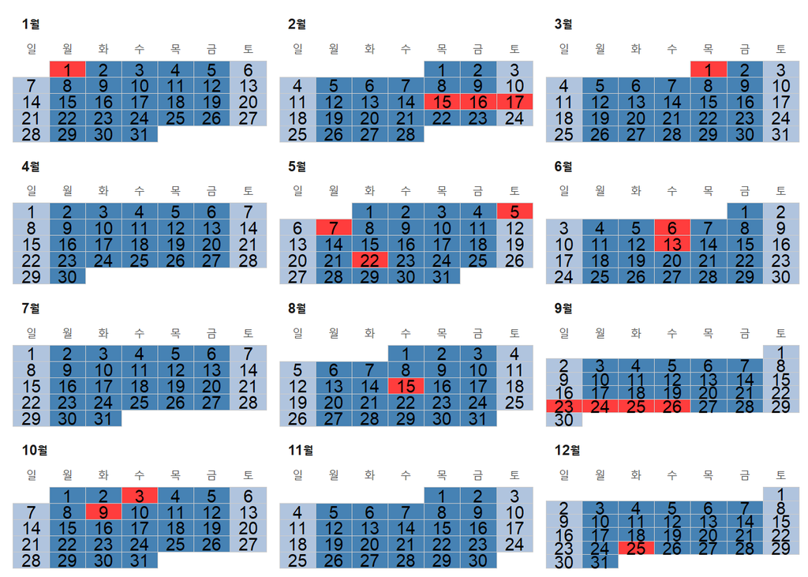

```r
# 3. 2018년 달력 시각화 ------

ggcal(cal_2018_df$휴일, cal_2018_df$휴일구분) +
  scale_fill_manual(values=c("주중"="steelblue", "휴일"="lightsteelblue", "공휴일"="#ff3d3d"))
```

[^1]: [공휴일 확인하기 : 공공데이터포털 API 예제, 작성자 Curycu](https://blog.naver.com/hancury/221057426711)